# 19BCE1717 Lab FAT

```r
cf
```

[output not shown]

#####10. Provide the visualization of frequency distribution of the resultant observations.

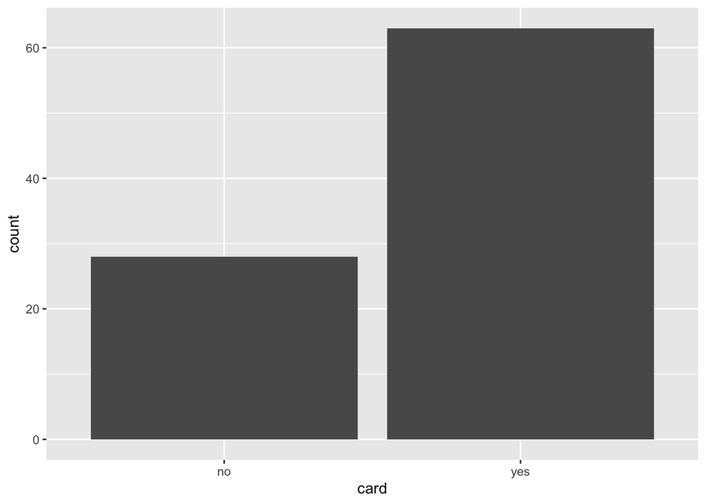

```r
ggplot(df9, aes(x=card))+geom_bar()
```

#####11. Visualize the summary statistics of expenditure value of self-employed and not self-employed applicants. Provide your inferences.

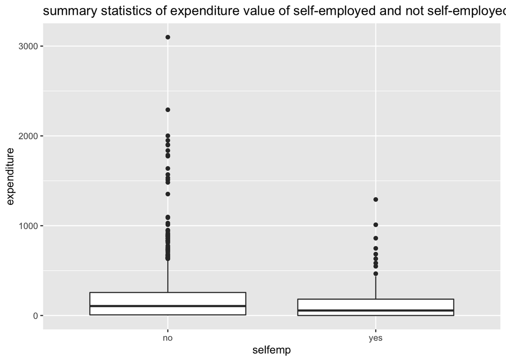

```r
ggplot(data=data, aes(x=selfemp, y=expenditure))+geom_boxplot() + labs(title = "summary statistics of expenditure value of self-employed and not self-employed applicants")
```

#####12. Does the age and expenditure of the applicants correlated? Justify your answer.

```r
cor(data$age, data$expenditure)
```

```
## [1] 0.015
```

```r
#INFERENCE: The value of correlation is 0.015 which is extremely low to have any significant impact. However, if we have to categorise it, we can say there is positive correlation as the value is > 0.
```

#####13. Predict the value of age based on other numerical values and compare various models with different combination of variables. Suggest a model with limited dependent variables that is better according to you. Justify your analysis.

```r
# label = age
# only numerical columns so drop the rest:
#NOTE: the col X is dropped as it is just an indexing columns and not useful for prediction
data_sub = subset(data, select = c(reports, income, share, expenditure, dependents, months, majorcards, active, age))
str(data_sub)
```

```
## 'data.frame':    1319 obs. of  9 variables:
##  $ reports    : int  0 0 0 0 0 0 0 0 0 0 ...
##  $ income     : num  4.52 2.42 4.5 2.54 9.79 ...
##  $ share      : num  0.03327 0.00522 0.00416 0.06521 0.06705 ...
##  $ expenditure: num  124.98 9.85 15 137.87 546.5 ...
##  $ dependents : int  3 3 4 0 2 0 2 0 0 0 ...
##  $ months     : int  54 34 58 25 64 54 7 77 97 65 ...
##  $ majorcards : int  1 1 1 1 1 1 1 1 1 1 ...
##  $ active     : int  12 13 5 7 5 1 5 3 6 18 ...
##  $ age        : num  37.7 33.2 33.7 30.5 32.2 ...
```

All int or num. Now we can proceed with the modelling.

```r
model1 <- lm(age~.,data=data_sub)
model1
```

```
##
## Call:
## lm(formula = age ~ ., data = data_sub)
##
## Coefficients:
## (Intercept)      reports       income        share  expenditure   dependents
##    24.70352     -0.07315      1.17579    -14.35954      0.00268      0.87179
##      months   majorcards       active
##     0.05995     -0.15002      0.14566
```

The Linear model is generated. The coefficients are displayed above.

```r
summary(model1)
```

```
##
## Call:
## lm(formula = age ~ ., data = data_sub)
##
## Residuals:
##    Min     1Q Median     3Q    Max
## -40.29  -4.97  -1.37   4.19  52.42
##
## Coefficients:
##              Estimate Std. Error t value Pr(>|t|)
## (Intercept)  24.70352    0.81498   30.31  < 2e-16 ***
## reports      -0.07315    0.18196   -0.40  0.68772
## income        1.17579    0.18270    6.44  1.7e-10 ***
## share       -14.35954    5.54333   -2.59  0.00969 **
## expenditure   0.00268    0.00200    1.34  0.18003
## dependents    0.87179    0.20062    4.35  1.5e-05 ***
## months        0.05995    0.00362   16.54  < 2e-16 ***
## majorcards   -0.15002    0.62032   -0.24  0.80894
## active        0.14566    0.03937    3.70  0.00022 ***
## ---
## Signif. codes:  0 '***' 0.001 '**' 0.01 '*' 0.05 '.' 0.1 ' ' 1
##
## Residual standard error: 8.6 on 1310 degrees of freedom
## Multiple R-squared:  0.29,   Adjusted R-squared:  0.286
## F-statistic: 66.9 on 8 and 1310 DF,  p-value: <2e-16
```

```r
sigma(model1)
```

```
## [1] 8.6
```

```r
confint(model1)
```

```
##                2.5 %  97.5 %
## (Intercept)  23.1047 26.3023
## reports      -0.4301  0.2838
## income        0.8174  1.5342
## share       -25.2343 -3.4848
## expenditure  -0.0012  0.0066
## dependents    0.4782  1.2654
## months        0.0528  0.0671
## majorcards   -1.3669  1.0669
## active        0.0684  0.2229
```

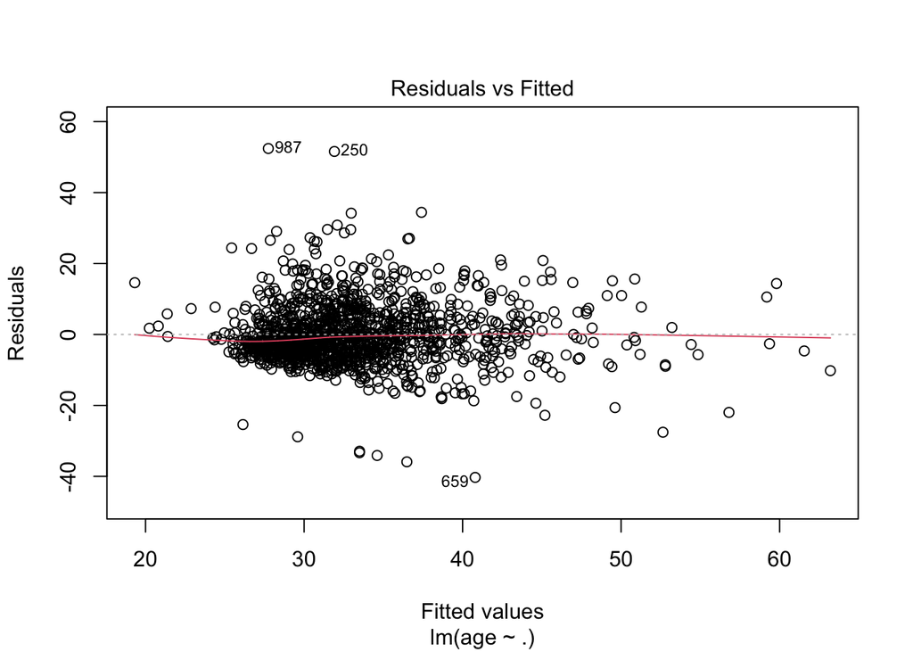

```r
plot(model1, 1)
```

As described above, the line is not perfectly horizontal and the scattered points are not aligning on the line which suggests the residuals are greated (vertical distance between the data and the line). Thus, not a very good model

The same is visualised below using the histogram plot

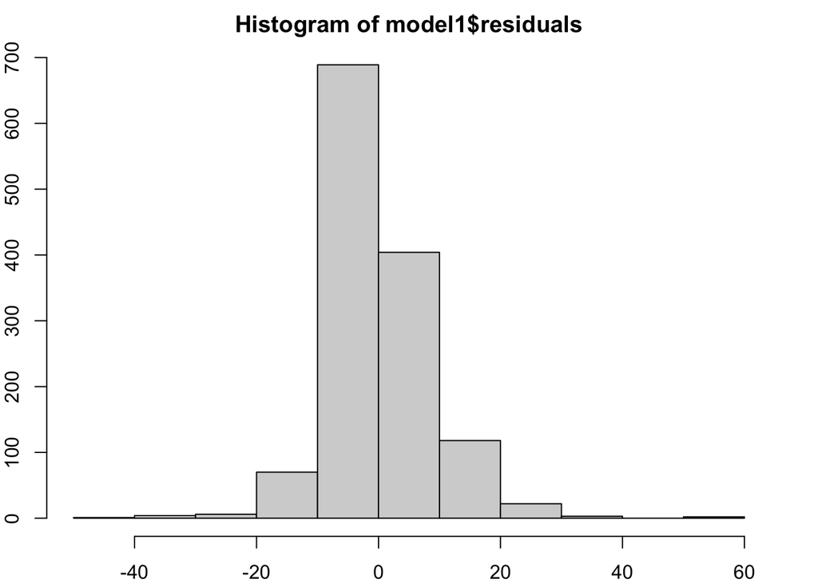

```r
par(mar=c(2,2,2,2))
hist(model1$residuals)
```

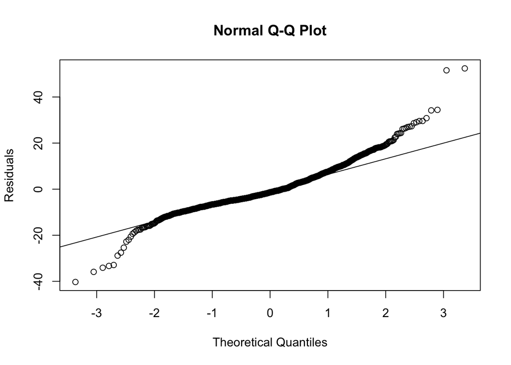

```r
qqnorm(model1$residuals,ylab = "Residuals")
qqline(model1$residuals)
```

#### Linear model using the significant attributes only

```r
sig_data = subset(data_sub, select = c(income, share, dependents, months, active, age))
str(sig_data)
```

```
## 'data.frame':    1319 obs. of  6 variables:
##  $ income    : num  4.52 2.42 4.5 2.54 9.79 ...
##  $ share     : num  0.03327 0.00522 0.00416 0.06521 0.06705 ...
##  $ dependents: int  3 3 4 0 2 0 2 0 0 0 ...
##  $ months    : int  54 34 58 25 64 54 7 77 97 65 ...
##  $ active    : int  12 13 5 7 5 1 5 3 6 18 ...
##  $ age       : num  37.7 33.2 33.7 30.5 32.2 ...
```

Training model 2 using statistically significant attributes:

```r
set.seed(123)
train_samples <- sig_data$age %>%
  createDataPartition(p=0.7,list=FALSE)
head(train_samples)
```

```
##      Resample1
## [1,]         2
## [2,]         5
## [3,]         6
## [4,]         7
## [5,]         8
## [6,]        10
```

```r
train <- sig_data[train_samples,]
test <- sig_data[-train_samples,]
model2 <- lm(age~.,data=train)
```

The dataset is split into train and test set and the model is trained - model2

Summary

```r
summary(model2)
```

```
##
## Call:
## lm(formula = age ~ ., data = train)
##
## Residuals:
##    Min     1Q Median     3Q    Max
## -34.12  -4.80  -1.32   4.23  33.66
##
## Coefficients:
##             Estimate Std. Error t value Pr(>|t|)
## (Intercept)  23.7352     0.6879   34.50  < 2e-16 ***
## income        1.4878     0.1663    8.94  < 2e-16 ***
## share        -8.3596     2.9341   -2.85  0.00448 **
## dependents    0.7837     0.2245    3.49  0.00051 ***
## months        0.0626     0.0042   14.91  < 2e-16 ***
## active        0.1072     0.0454    2.36  0.01847 *
## ---
## Signif. codes:  0 '***' 0.001 '**' 0.01 '*' 0.05 '.' 0.1 ' ' 1
##
## Residual standard error: 8.1 on 919 degrees of freedom
## Multiple R-squared:  0.319,  Adjusted R-squared:  0.316
## F-statistic: 86.2 on 5 and 919 DF,  p-value: <2e-16
```

INFERENCE: The R squared value is now 0.319 for model 2 using statistiaclly significant attributes. There is an improvement in the accuracy from the model 1 but we cannot really compare them together because the train size and the sample are different. For this model 2, we used 0.7 of the data to train the model, while for the model 1 we used all the data. Although there is an increase, we cannot say this is the best prediction algorithm as the r squared value is still a little low. we can now try the same using the highly correlated attribtues to see if there is any improvement.

##### Prediction accuracy:

```r
pred <- model2 %>%
  predict(test)
R2 <- R2(pred,test$age)
R2
```

```
## [1] 0.23
```

```r
RMSE <- RMSE(pred,test$age)
RMSE
```

```
## [1] 9.5
```

R squared is 0.23 for the test data explaining 0.23 of the dataset!

##### Highly correlated attributes:

```r
#Correlation wrt age
cols = colnames(data_sub)
for (c in cols) {
  print(paste("Column", c, ": ", cor(data_sub[[c]],data_sub$age)))
}
```

```
## [1] "Column reports :  0.0440885131796215"
## [1] "Column income :  0.324653198672765"
## [1] "Column share :  -0.115697038102125"
## [1] "Column expenditure :  0.0149476980586069"
## [1] "Column dependents :  0.212146432378923"
## [1] "Column months :  0.436425540492553"
## [1] "Column majorcards :  0.00977668702986108"
## [1] "Column active :  0.181069714603408"
## [1] "Column age :  1"
```

INFERENCE: The attributes months, active, dependents and income are considered as they are the ones with decent level of correlation values. Negative values does not mean low, it means there is a negative correlation and the reason I did not take share column is because the value is still very close to 0.

```r
high_cor = subset(data_sub, select = c(months, active, dependents, income, age))
str(high_cor)
```

```
## 'data.frame':    1319 obs. of  5 variables:
##  $ months    : int  54 34 58 25 64 54 7 77 97 65 ...
##  $ active    : int  12 13 5 7 5 1 5 3 6 18 ...
##  $ dependents: int  3 3 4 0 2 0 2 0 0 0 ...
##  $ income    : num  4.52 2.42 4.5 2.54 9.79 ...
##  $ age       : num  37.7 33.2 33.7 30.5 32.2 ...
```

Training model 3 using high correlated attributes:

```r
set.seed(100)
train_samples <- high_cor$age %>%
  createDataPartition(p=0.7,list=FALSE)
head(train_samples)
```

```
##      Resample1
## [1,]         1
## [2,]         2
## [3,]         4
## [4,]         5
## [5,]         6
## [6,]         7
```

```r
train <- high_cor[train_samples,]
test <- high_cor[-train_samples,]
model3 <- lm(age~.,data=train)
```

The dataset is split into train and test set and the model is trained - model3

Summary

```r
summary(model3)
```

```
##
## Call:
## lm(formula = age ~ ., data = train)
##
## Residuals:
##    Min     1Q Median     3Q    Max
## -39.90  -5.14  -1.44   4.19  53.35
##
## Coefficients:
##             Estimate Std. Error t value Pr(>|t|)
## (Intercept) 23.34988    0.71147   32.82  < 2e-16 ***
## months       0.06084    0.00467   13.02  < 2e-16 ***
## active       0.15790    0.04664    3.39  0.00074 ***
## dependents   1.01442    0.24253    4.18  3.2e-05 ***
## income       1.33533    0.18985    7.03  3.9e-12 ***
## ---
## Signif. codes:  0 '***' 0.001 '**' 0.01 '*' 0.05 '.' 0.1 ' ' 1
##
## Residual standard error: 8.8 on 920 degrees of freedom
## Multiple R-squared:  0.268,  Adjusted R-squared:  0.265
## F-statistic: 84.3 on 4 and 920 DF,  p-value: <2e-16
```

INFERENCE: The model 3 is haing r squared value less than the model 2 with significant attributes and hence the model 2 appears to be the best overall model.

```r
pred <- model3 %>%
  predict(test)
R2 <- R2(pred,test$age)
R2
```

```
## [1] 0.33
```

```r
RMSE <- RMSE(pred,test$age)
RMSE
```

```
## [1] 8
```

R squared is 0.33 for the test data which is greated than the model 2 scenario.

CONCLUSION: Even though the train data r squared value for model 2 using significant attributes is greater than the model 3 using high correlated attributes, the test data r squared is 0.33 for model 3 while it is only 0.23 for model 2. Although we cannot definitively conclude that the one is better than the other, we can say that model 2 is better in terms of train set while model 3 is better in terms of test set. In real life, we will encounter more and more test set to predict and thus using model 3 appreas to be a better solution. However, other modelling technique should be explored as the r quared is low for all 3 models using inear regression.